# Transition or Tradition? Analyzing 17 Years of Presidential Reports in Mexico Through Leadership Changes

Candidate ID: 27529

2024-04-17

word count: 2995

## 1. Abstract

This work analyzes 17 years of presidential reports and speeches from three Mexican administrations, focusing on the period when power shifted among three different parties after 70 years of single-party rule. Web scraping and quantitative text analysis techniques were used to collect and explore data from presidential reports and speeches. Structural Topic Modeling was then applied to detect key themes and assess how political agendas from each governmental change were reflected in these discursive narratives.

## 2. Introduction

With this work I seek to answer the question: *What, if any, are the most prevalent topics in each presidential period, during the last 3 six-year terms?* The goal is to identify the most prevalent topics during each term and correlate them with related economic indicators such as female labor participation, unemployment rate, women’s representation in parliament and budget allocations for health, economic development, social development, and gender.

The methodology for this purpose included:

1. Collecting speeches and reports via web scraping, (initially only speeches were considered but given the small amount of data after processing, it was decided to extend it).
2. Acquiring macroeconomic data from the World Bank and Ministry of Finance ensuring comparability and deflation to 2023 prices when necessary.
3. Text processing, including a detailed cleaning, corpus creation, tokenization, and removal of recurring irrelevant words. The document-feature matrix ended up with 17 documents and 3,262 features.
4. Exploratory Data Analysis (EDA): Quantitative text analysis techniques were employed, including word clouds, tf-idf metrics, dictionary applications, lexical diversity, and sentiment analysis.
5. Topic Identification: Structural Topic Modeling revealed recurring themes indicative of persistence political agendas. Variations in emphasis on health and well-being, education, and security were noted across different political parties. Trends in gender and care-related discussions over time were also analyzed.
6. Correlation analysis between theta values for each topic in each document and diferent macroeconomic variables.
7. Use of visualization tools such as sankey diagram and ToolDAvis for interactive visualization hosted on https://michellepapadakis.github.io/PSFMY459/

## 3. Motivation

Mexico’s political landscape has undergone significant shifts, with the three major parties exchanging power over the last 18 years. In 2000, presidential candidate Vicente Fox ended 70 years of uninterrupted one-party rule in Mexico by the Institutional Revolutionary Party (PRI). Currently, the party’s principles include nationalism, freedoms, democracy, and social justice, and according to its statutes, it promotes the exercise of power towards the economic, political, social, and cultural development of Mexico, maintaining an ideological tendency that links it to the social democratic current. (PRI, 1978). After a series of conflicts, corruption, and electoral fraud, there was a political turnover in 2000 to the conservative National Action Party (PAN), which aligns with Christian democracy and a humanist doctrine according to its official documents (PAN, 1939). PAN ruled from 2000 to 2012, with Felipe Calderón Hinojosa elected in 2006, giving continuity to the political project of the PAN (Lawson, Chappell. 2007). However, Calderón’s term was marked by a war against drug trafficking that led to extreme violence, resulting in the PRI’s return to power in 2012 with former President Enrique Peña Nieto. Due to high crime rates, violence, unsolved massacres, clandestine graves, assassinations of journalists, and general insecurity, coupled with underperforming structural reforms, notably in education and energy, there was significant social discontent. This paved the way for the National Regeneration Movement (MORENA) to win in 2018, with the party’s founder, Andrés Manuel López Obrador, leading the “Together We Will Make History” coalition. His administration promised better living standards and the end of political privileges to improve the population wellbeing.(Del Castillo, 2018). In Mexico, the three main sources of discontent that led to López Obrador’s victory, according to Greene, K. and Sánchez-Talanquer, M. (2018), were firstly, the transition to democracy and the free market did not meet expectations for prosperity. Secondly, drug-related violence has dramatically increased since 2006, with 2017 being the deadliest year on record. Finally, structural reforms, notably the educational reform in 2013, were quickly implemented but did not produce the expected results.

This work analyzes the period from 2007 to 2023, covering three presidential terms with three different parties in power, aiming to offer a longitudinal perspective to discern policy focus trends and shifts, if any. Background research can be found in Torres et al. (2020), which includes a comparative analysis from 1983 to 2013 of presidential reports (one per year), an analysis of President Felipe Calderón’s speeches to legitimize the so-called “War on Drugs” (Vazquez Moyers, 2014), as well as cases of statistical text analysis for various Latin American countries like Uruguay (Vernazza Mañana & Vicente Villardón, 2021) and Peru (Chung Pinzás & Inche Mitma, 2024).

## 4. Description of the corpus

The corpus is composed of 17 documents, corresponding to 17 years of presidential reports, each document containing the presidential report and the speech issued by the president on the occasion of the delivery of the report to the congress. Derived from an initial analysis which revealed insufficient information for analysis, it was decided to also include the content of the presidential report within the same variable. The data is from 2007 to 2023, since the 2024 presidential report will be made on September 1 of this year. Therefore, 6 documents for President Felipe Calderón are integrated, corresponding to the speeches from 2007 to 2012, 6 for President Enrique Peña Nieto, corresponding to 2013 to 2018 reports and 5 documents for President López Obrador, corresponding to 2019 to 2023.

Text data was retrieved mainly through the Center for the Study of Democracy and Elections of the Metropolitan Autonomous University of Mexico (CEDE,2024), the mexican government website and one from the national newspaper “El Universal”. Finally, due to a change in the domain of the official website of the government of the republic starting in 2012, the presidential reports of the government of Felipe Calderón were recovered from his personal page. The texts were retrieved using scrapping techniques as well as processes for the automated downloading and extraction of data from pdf documents.

Regarding economic data, the female labor force participation rate (percentage of female population aged 15-64), the unemployment rate (percentage of total labor force), and the percentage of women in parliamentary seats (percentage of total seats) were obtained from the World Bank, using their wbstats package. For the expenditure analysis, data were extracted from the Mexican Ministry of Finance. This data, classified according to the functional classification of expenditure (SHCP, 2008), included “economic development” expenditures which cover spending on commercial affairs, and sectors such as agriculture, science and innovation, tourism, transportation, and mining. Expenditures for “social development” —encompassing education, health, housing, and social and environmental protection— were also retrieved, along with “gender-related” expenditures, a budgetary item initiated in 2006 to encourage gender equality, as well as health sector spending. All budget data were presented as a percentage of the total annual expenditure, adjusted for inflation where necessary for comparisson.

The text processing involved several steps such as: 1. Cleaning up the raw text, including the removal of numbers, links and symbols, lowercase it, elimination of common words and proper nouns. 2. Creation of the corpus and tokenization of it, to which the elimination of stopwords, numbers and punctuation was extended. This step was reinforced through a manual removal of a list of Spanish pronouns, as well as a number of words irrelevant to the context that showed high frequency. 3. The data feature matrix was created, where again, taking care of the order of the rules, a general cleaning of the terms was done. The matrix came out at the end with 17 documents, and 3,262 features.

Before undertaking the Structural Topic Modeling analysis detailed in the following section, I conducted an exploratory data analysis. This initial analysis included assessing the total word count per document (Figure 1), identifying the most significant words in the text using Term Frequency-Inverse Document Frequency (Figure 2), and examining the variation in word usage across different presidencies (Figure 3). Additionally, the lexical diversity within each discourse was calculated (Figure 4), and sentiment analysis was performed on the text from each year (Figure 5).

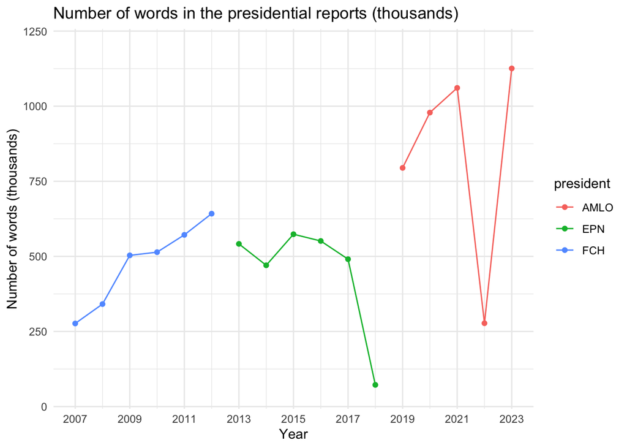

*Figure 1: Total number of words per document*

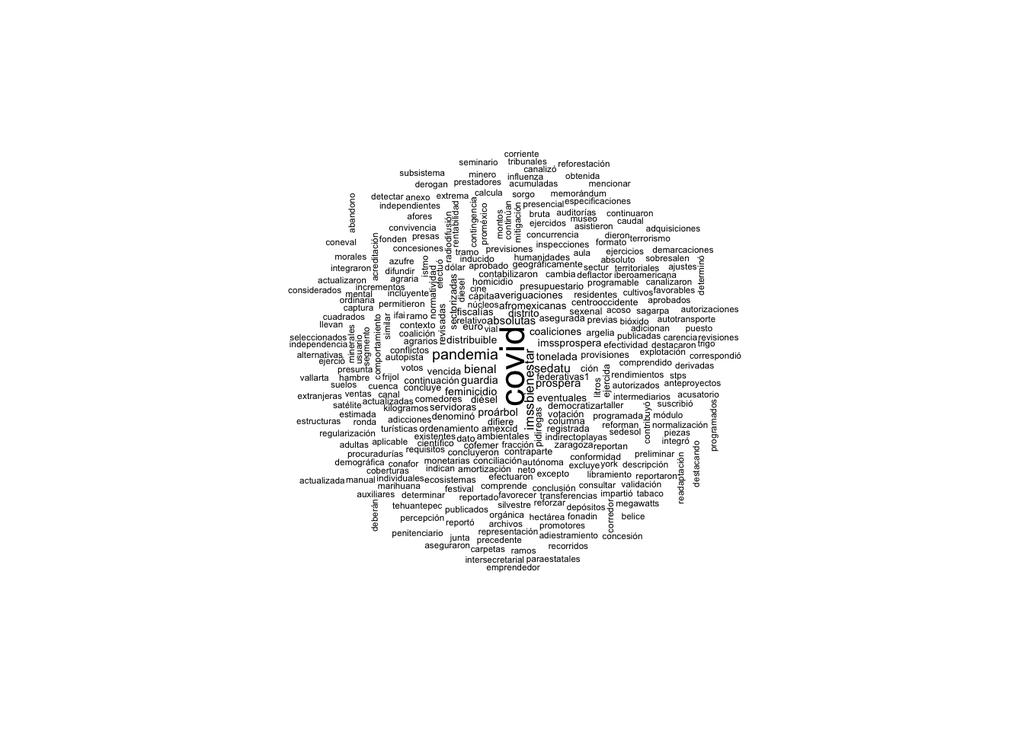

*Figure 2: Most relevant words weighted by tf-idf*

Figure 2 highlights key terms from presidential speeches, with terms like “COVID,” “pandemic,” “well-being programs” (implied by “IMSSBIENESTAR”), and legal and safety-related terms such as “prosecution,” “homicides,” and “investigations” featuring prominently. The prevalence of these terms, particularly those related to health and safety, likely reflects the socio-political challenges and priorities of the times they were spoken.

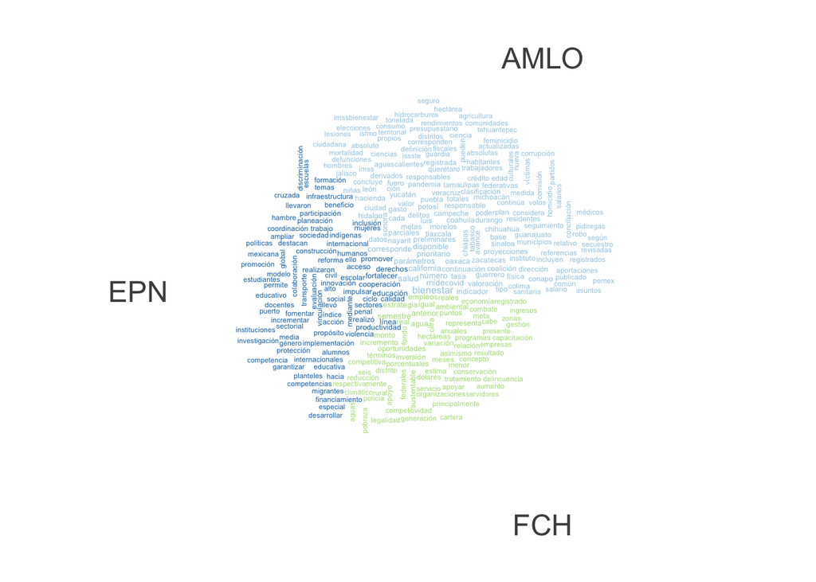

*Figure 3: Most relevant words weighted by tf-idf by president*

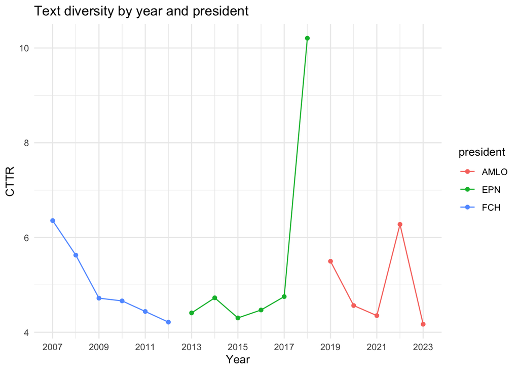

*Figure 4: Lexical diversity by year*

The lexical diversity plot utilizes the Corrected Type-Token Ratio to adjusts for text length differences, which is particularly valuable here as Figure 1 revealed significant variations in the length of reports and speeches. The graph exhibits exceptionally high lexical diversity in Peña Nieto´s 2018 report, contrasting with the lower diversity observed in López Obrador’s 2023 speech, similar in indicator to Felipe Calderón’s 2012 report.

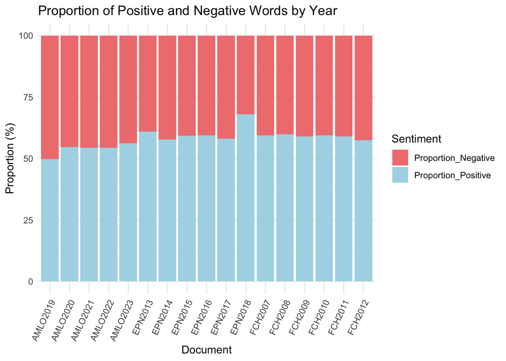

*Figure 5: Sentiment analysis: proportion of positive and negative terms*

The sentiment analysis of presidential speeches, as seen in figure 5, revealed a tendency towards positive language usage. Interestingly, Peña Nieto’s speech in 2018 had the most positive language, which contrasted sharply with next year López Obrador’s 2019 speech that recorded the least positive terms.

## 5. Description of the methods

To refine the textual data analysis, I used an unsupervised machine learning algorithm well-suited for identifying structural topics in texts. I applied the Structural Topic Model (STM), because, among other advantages, it allows for the incorporation of metadata covariates, which can help to understand how topics relate to different variables, which is the main objective of this work. It also helps to identify the most relevant topics in the corpus, which can be particularly useful when dealing with large amounts of text data or data that overlaps in content, like presidential reports (See Mostafa, M.M., 2022 and Roberts et al., 2013, 2014). Given that choosing the right K is crucial—as too low a K may lead to overly broad categories, while too high a K can result in many insignificant topics—the ideal K was inlfuenced by using the *searchK* method, as shown in Figure 6, and further refined by the *selectModel* method. Here, I took the optimal K result from obtaining the heldout values calculated for each of the estimated STM models with different values of K. The optimal K is the number associated with the maximum value in the list of heldout values. Initially, the optimal value found was 10 K; however, after further manual testing and adjustments, K was adjusted to 3 for better topic coherence.

Further steps included estimating how these topics related to ‘party’ and ‘year’ covariates, enabling comparisons across political parties and years. To address two themes that were not initially captured in the topic analysis, I created dictionaries with key terms for each theme. These dictionaries helped track relevant word occurrences in the texts.

I exracted theta values for each resulting topic across documents to describe the thematic composition of the documents and correlate them with various economic indicators, summarized in a correlation matrix at the end.

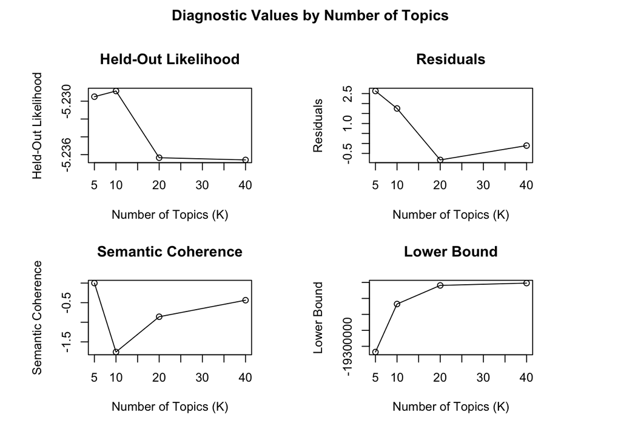

*Figure 6. Finding the optimal range of latent topics through model-fit statistics*

## 6. Results.

### 6.1 Structural Topic Model

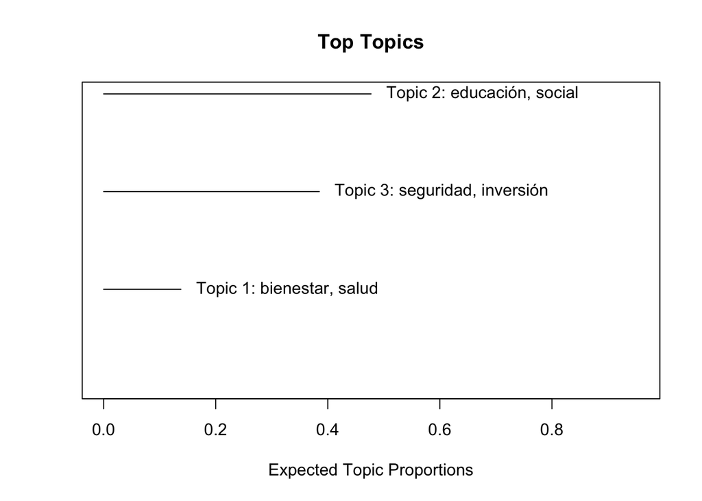

*Figure 7: Top Topics and their proportion in the documents*

### 6.2 Topic prevalence over time

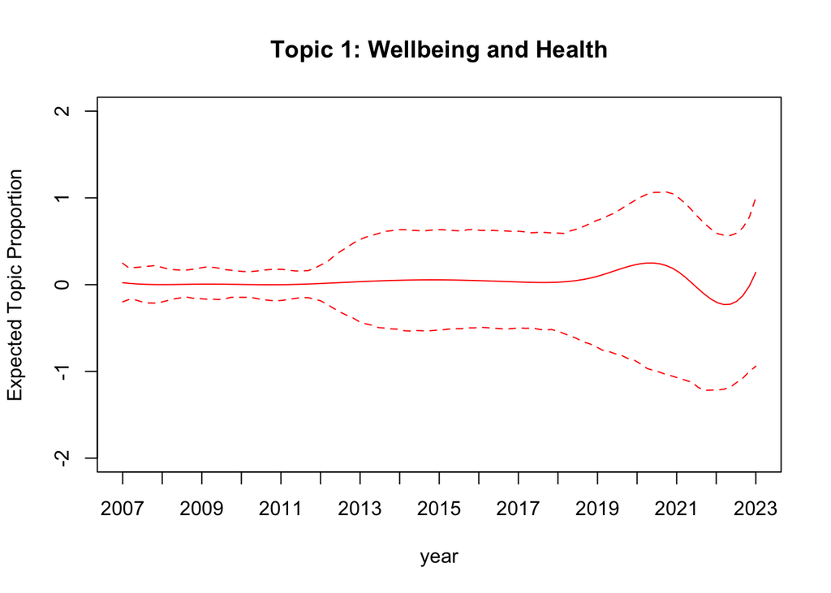

*Figure 8: Topic 1: Health and well-being over time*

On the other hand, Figure 9 shows that education saw an increase from 2012 to around 2018, followed by a drop in 2020 and a recover in 2022. Finally, Topic 3, reached its peak from 2007 to 2013 and then stabilized. This suggests that the prevalence of the topics has varied over time with marked emphases in the years coinciding with government changes.

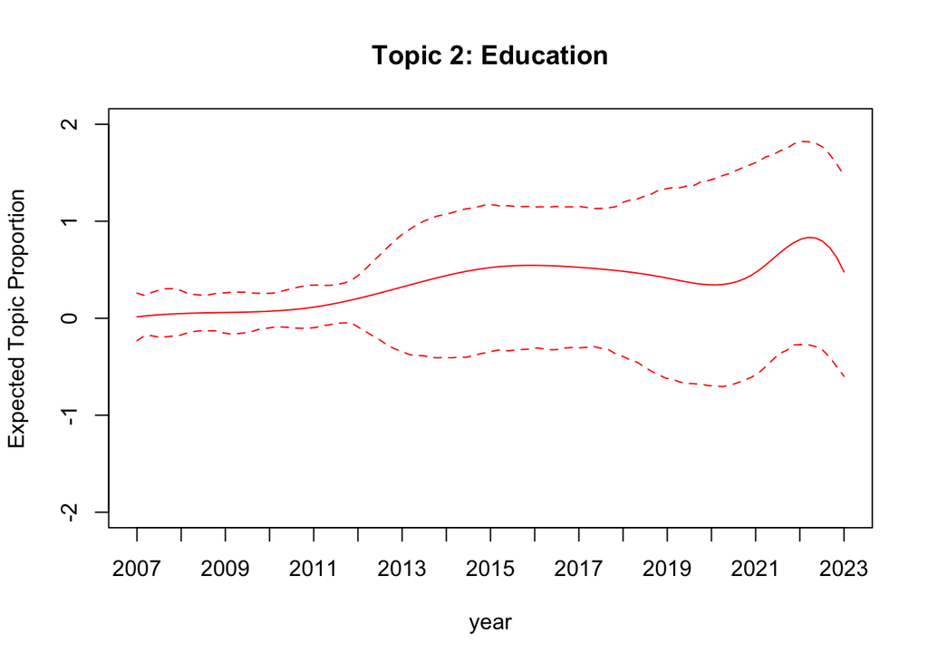

*Figure 9: Topic 2: Education over time*

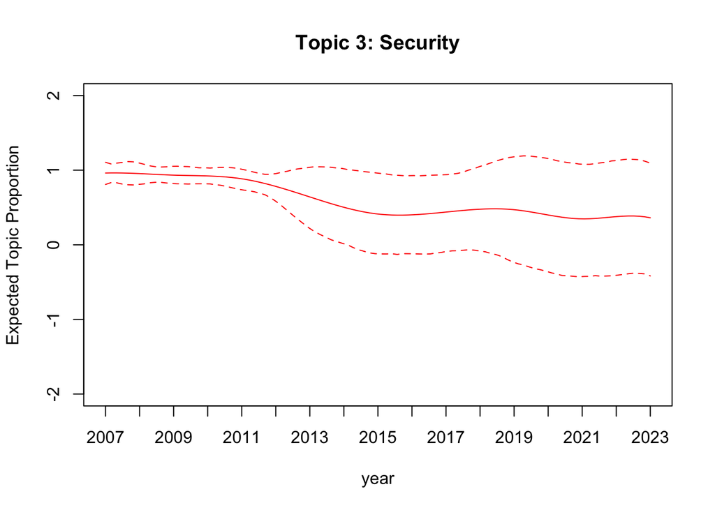

*Figure 10: Topic 3: Security over time*

### 6.3 Topic prevalence by political party

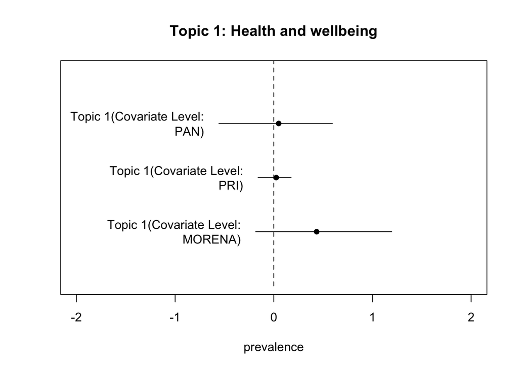

*Figure 11: Topic 1: Health and well-being by party*

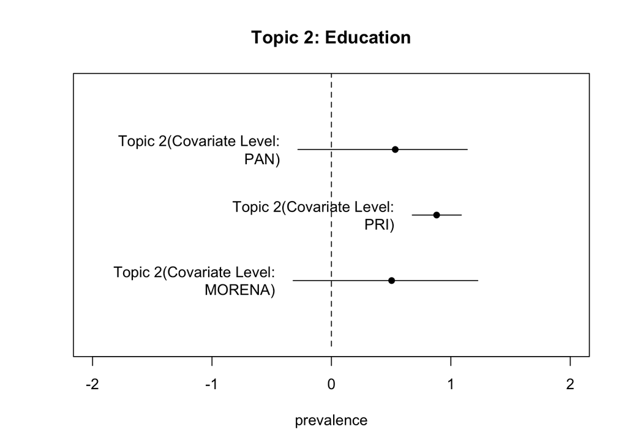

*Figure 12: Topic 2: Education by party*

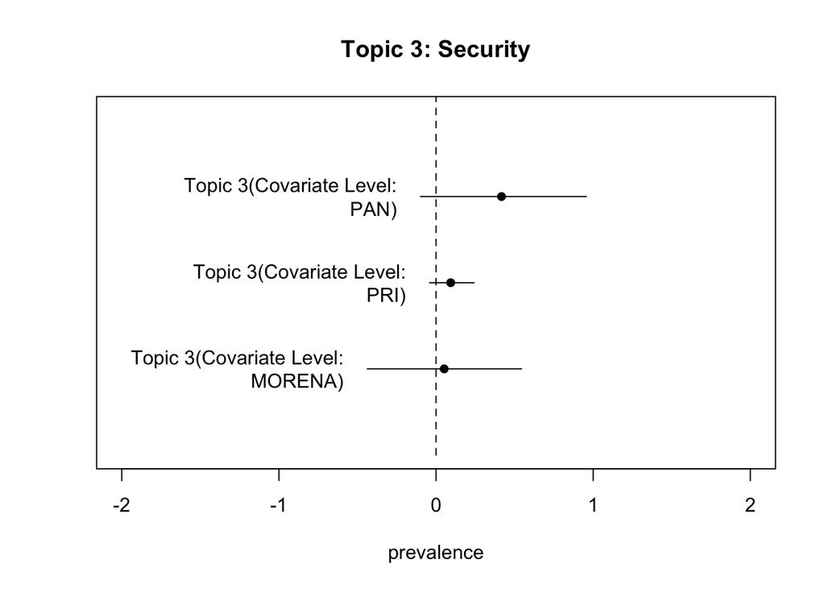

*Figure 13: Topic 3: Security by party*

Given Mexico’s significant gender inequality (IMF, 2024), further analysis examined gender and care-work themes. I created dictionaries to track these terms in presidential speeches, analyzing their occurrence in a term matrix weighted by frequency. Figures 14 and 15 chart the annual variation of these themes in the political arena.

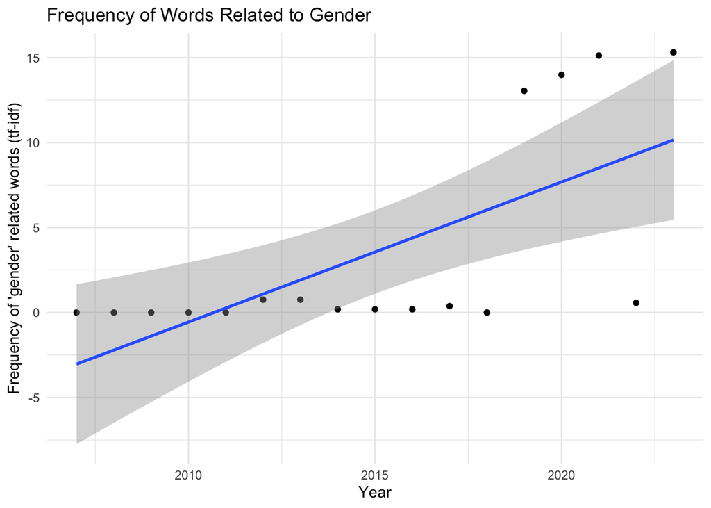

*Figure 14: Gender mentions over time*

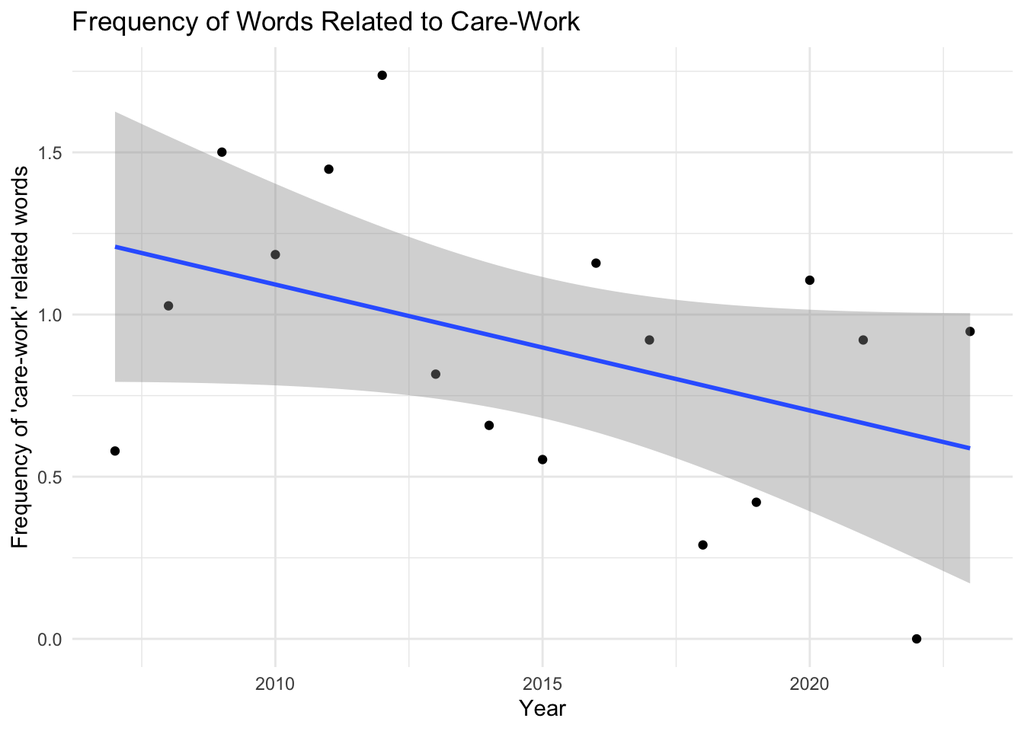

*Figure 15: Care mentions over time*

### 6.4 Correlation analysis

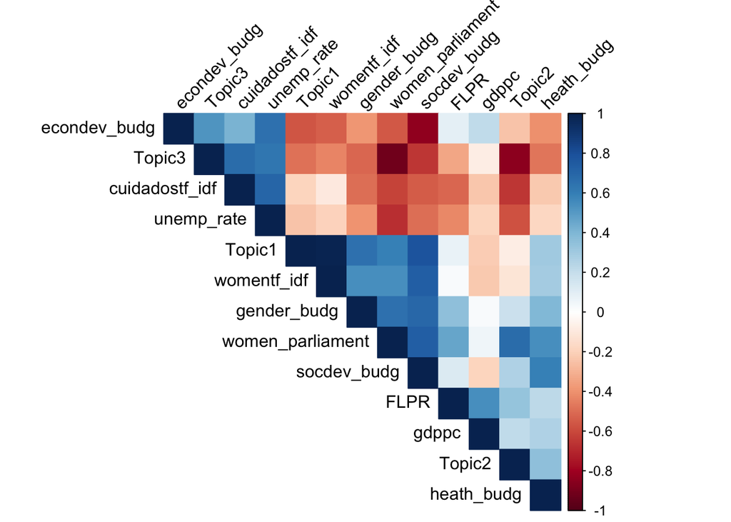

*Figure 16: Correlation matrix of topics and economic and social indicators*

Final visualization techniques were utilized to depict the topic distribution in presidential speeches. A Sankey diagram and an interactive topic visualization tool, hoosted here: https://michellepapadakis.github.io/PSFMY459/. In Figure 17, the diagram clearly shows a dominance of health and well-being themes in the speeches of the president from the MORENA party, which have increased over the years. This strongly aligns with the party’s political discourse on welfare and a dignified life. Conversely, the PRI party has consistently emphasized education in its speeches, aligning with its national project and educational reform. Meanwhile, the PAN party has demonstrated a strong focus on security themes.

[interactive chart not shown]

*Figure 17: Sankey diagram of topic distribution by party*

## 7. Conclusion

Education, Security, and Health and Wellbeing topics consistently appear, influenced by the party in power. Despite the overlapping political agendas, the analysis successfully identifies specific structural themes predominant in each party. This pattern suggests that while political leadership changes, certain themes persist, reflecting a complex interplay of tradition and transition in the political narrative. The difficulty in distinguishing more top topics from stm likely stems from these overlapping agendas; however, this works still manages to highlight the predominant themes for each party. These findings may indicate that shifts in government don’t always lead to drastic changes in thematic focus but rather reflect a gradual evolution in addressing both longstanding and emergent societal needs.

## 8. References

- Calderón, Felipe. “Informe de Gobierno 2007-2012.” Accessed April 2024. https://felipe.mx/.
- Centro de Estudios de la Democracia y Elecciones (CEDE). “Discursos presidenciales” [Presidential speeches]. Metropolitan Autonomous University of Mexico (UAM). Accessed April 2024. https://cede.izt.uam.mx/?page_id=2999
- Chung Pinzás, A. R., and Inche Mitma, J. L. “Minería de datos aplicada a los discursos presidenciales de Pedro Castillo Terrones en Perú” [Data mining applied to the presidential speeches of Pedro Castillo Terrones in Peru]. Revista De Comunicación 23, no. 1 (2024): 141–156. https://doi.org/10.26441/RC23.1-2024-3417.
- Del Castillo, Graciana. “El Plan Nacional de AMLO para México es Motivo de Optimismo” [AMLO’s National Plan for Mexico is a cause for optimism]. LSE Latin America and Caribbean Blog. July 06, 2018 https://blogs.lse.ac.uk/latamcaribbean/2018/07/06/el-plan-nacional-de-amlo-para-mexico-es-motivo-de-optimismo/.
- El Universal. “Texto íntegro del mensaje de Felipe Calderón en su sexto informe de gobierno” [Full text of Felipe Calderón’s message in his sixth government report], El Universal, September 2012. https://archivo.eluniversal.com.mx/notas/868097.html
- Greene, Kenneth, and Mariano Sánchez-Talanquer. “Latin America’s Shifting Politics: Mexico’s Party System Under Stress.” Journal of Democracy 29, no. 4 (October 2018): 31-42. https://www.journalofdemocracy.org/articles/latin-americas-shifting-politics-mexicos-party-system-under-stress/.
- International Monetary Fund. Western Hemisphere Dept. “Mexico: Selected Issues.” IMF Staff Country Reports, 2023, A001. Accessed April 2024. https://www.elibrary.imf.org/view/journals/002/2023/357/002.2023.issue-357-en.xml .
- Lawson, Chappell. “How Did We Get Here? Mexican Democracy After the 2006 Elections.” PS: Political Science & Politics 40, no. 1 (2007):45-48 https://www.jstor.org/stable/20451890 .
- Moyers, A. V. “La guerra contra el narcotráfico en el sexenio de Felipe Calderón: Análisis del discurso” [The war against drug trafficking during the six-year term of Felipe Calderón: Analysis of the speech], (2014) https://ri-ng.uaq.mx/handle/123456789/745.
- Mostafa, M.M. “A one-hundred-year structural topic modeling analysis of the knowledge structure of international management research.” Qual Quant 57 (2023): 3905–3935. https://doi.org/10.1007/s11135-022-01548-w.
- Partido Acción Nacional. “Principios de Doctrina.”, [Principles of Doctrine], (1939). https://www.pan.org.mx/documentos/principios-de-doctrina.
- Partido Revolucionario Institucional. “Declaración de Principios”, [Declaration of Principles], (1978) https://pri.org.mx/ElPartidoDeMexico/NuestroPartido/Documentos.aspx.
- Presidencia de la República. “Mensajes con Motivo del Informe de Gobierno 2012-2018”, [Messages on the occasion of the Government Report, 2012-2018], Gobierno de México. Accessed April 2024. https://www.gob.mx/epn.
- Presidencia de la República. “Versión Estenográfica del Mensaje con Motivo del Informe Gobierno, 2019-2023” [Stenographic Version of the Message on the occasion of the Government Report, 2019-2023], Gobierno de México. Accessed April 2024. https://www.gob.mx/presidencia.
- Roberts, M. E., Stewart, B. M., Tingley, D., Lucas, C., Leder-Luis, J., Gadarian, S. K., Albertson, B., and Rand, D. G. “Structural Topic Models for Open-Ended Survey Responses.” American Journal of Political Science 58, no. 4 (2014): 1064-1082. https://doi.org/10.1111/ajps.12103.
- Torres, I. B., Urrutia, J. A. V., María de Jesús, O., and Armas, H. J. H. “Minería de datos aplicada al análisis de los discursos presidenciales de México.”, [Data mining applied to the analysis of Mexican presidential speeches], Tla-melaua: revista de ciencias sociales, no. 48 (2020): 89-105. http://portal.amelica.org/ameli/jatsRepo/47/471772005/index.html.
- Vernazza Mañana, E., and Vicente Villardón, J. “Discursos presidenciales en Uruguay: enfoque desde el análisis estadístico de texto” [Presidential speeches in Uruguay: approach from statistical text analysis], Cuadernos Del CIMBAGE 1, no. 23 (2021): 21-46. https://ojs.econ.uba.ar/index.php/CIMBAGE/article/view/2054.
- Warin, Thierry. “Structural Topic Modeling.” Shiny. Accessed April 2024. https://warin.ca/shiny/stm/#section-evaluate.

## 9. Annex

### 9.1 Top words by top topic

```
##   Topic Highest_Prob.1 Highest_Prob.2 Highest_Prob.3 Highest_Prob.4
## 1     1                     bienestar          salud         número
## 2     2                     educación         social          salud
## 3     3                     seguridad      inversión         social
##   Highest_Prob.5 Highest_Prob.6 Highest_Prob.7 Highest_Prob.8  Highest_Prob.9
## 1           mide         social      seguridad     california     federativas
## 2      seguridad       derechos       mediante        mujeres       inversión
## 3      programas      educación          salud    federativas infraestructura
##   Highest_Prob.10    FREX.1     FREX.2        FREX.3         FREX.4   FREX.5
## 1           datos     covid  bienestar    parámetros    prioritario     mide
## 2       programas inclusión innovación     violencia implementación impulsar
## 3        anterior  semestre    empleos oportunidades           real    igual
##          FREX.6     FREX.7       FREX.8     FREX.9    FREX.10      Lift.1
## 1  continuación valoración    parciales disponible  coalición coaliciones
## 2 productividad   docentes  vinculación     acceso planeación     sexenio
## 3    representa   distrito porcentuales     puntos    anuales    proárbol
##          Lift.2       Lift.3       Lift.4    Lift.5      Lift.6       Lift.7
## 1 imssbienestar        covid     tonelada  pandemia feminicidio sectorizadas
## 2      prospera federativas1 imssprospera    hambre   comedores aprendizajes
## 3   competitiva         ifai   superación megawatts    programó       diesel
##      Lift.8     Lift.9         Lift.10 Score
## 1 coalición      votos   afromexicanas     1
## 2   cruzada incluyente   desaparecidas     2
## 3 acuíferos criminales centrooccidente     3
```

*Output 1: Top words in each topic*

[figure not shown]

### 9.2 Topic Prevalence by Party

*Annex Figure 1: Comparison of MORENA and PRI on each topic*

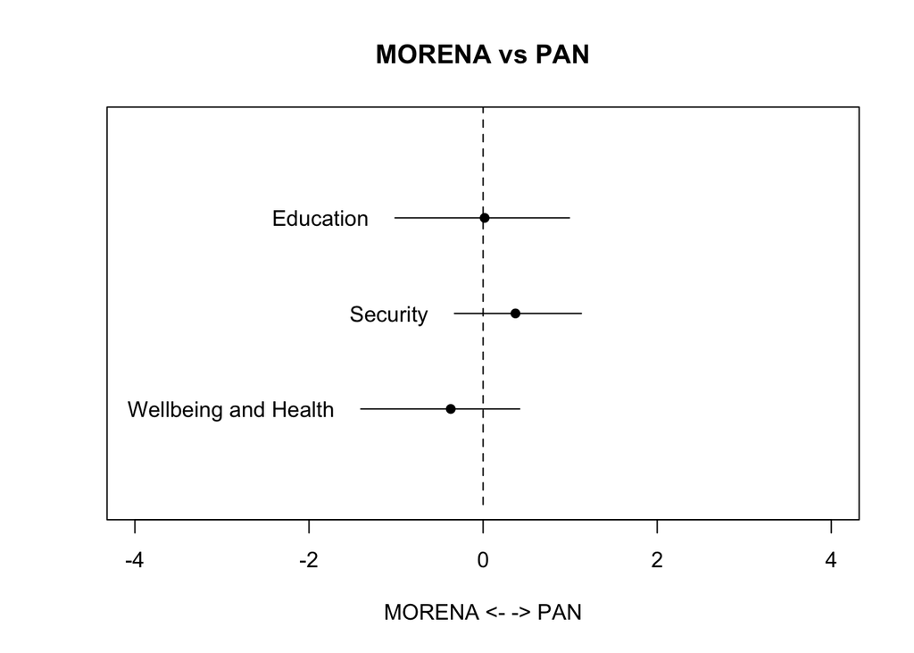

*Annex Figure 2: Comparison of MORENA and PAN on each topic*

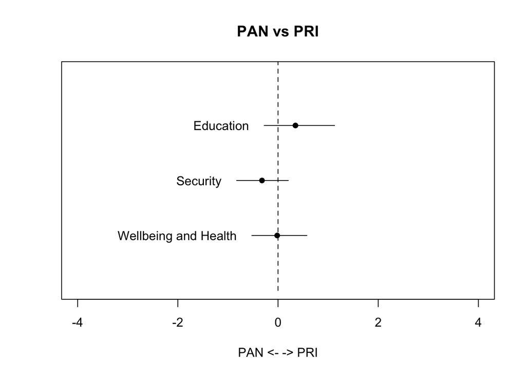

*Annex Figure 3: Comparison of PAN and PRI on each topic*

## 10. Code Appendix

```r
knitr::opts_chunk$set(echo = FALSE, tidy.opts=list(width.cutoff=60), tidy=TRUE)


options(repos = c(CRAN = "https://cloud.r-project.org"))
webshot::install_phantomjs()


#Loading all libraries used in the exercise
packages <- c ("rvest", "dplyr", "xml2", "stringr", "RSelenium", "tidyverse", "httr", "ggplot2", "scales", "httr", "pdftools", "quanteda","wbstats", "readr", "readxl","stm", "quanteda.textstats", "quanteda.textplots", "stopwords", "LDAvis", "corrplot", "networkD3", "webshot2", "servr", "kableExtra", "knitr", "servr", "formatR", "chromote")

installed_packages <- packages %in% rownames(installed.packages())
if (any(installed_packages == FALSE)) {
  install.packages(packages[!installed_packages])
}
invisible(lapply(packages, library, character.only = TRUE))

################################################################################
### 1. Obtaining the data
#### 1.1 Obtaining the text data from the web
################################################################################

# PART 1. of text retrieval  ###################################################
#This chunk of code is to extract the speech of the last 3 presidents of Mexico.
#Given the restictions on access, the code is divided in two parts.
#The first part is to extract the text from the pages of the last 2 presidents
#of Mexico, AMLO and EPN. The second part is to extract the first 5 pdf files of
#the president Calderon obtained from the archives of the Metropolitan Autonomous
#University of Mexico (UAM). The last speech  of Calderon is obtained from the
#archive of one of the official newspaper in Mexico, "El Universal".

################################################################################

# rD <- rsDriver(browser = "firefox", port = free_port(random = TRUE), chromever = NULL)
# remDr <- rD$client
# base_url <- "https://www.gob.mx/presidencia/articulos/version-estenografica-del-primer-informe-de-gobierno?idiom=es"
# remDr$navigate(base_url)
#
#
################################################################################
#
########## Pages for president EPN
#
# link_epn <- c("https://www.gob.mx/epn/prensa/mensaje-del-presidente-de-los-estados-unidos-mexicanos-licenciado-enrique-pena-nieto-con-motivo-de-su-primer-informe-de-gobierno",
#               "https://www.gob.mx/epn/prensa/mensaje-del-presidente-de-los-estados-unidos-mexicanos-licenciado-enrique-pena-nieto-con-motivo-de-su-segundo-informe-de-gobierno",
#               "https://www.gob.mx/epn/prensa/mensaje-del-licenciado-enrique-pena-nieto-presidente-de-los-estados-unidos-mexicanos",
#               "https://www.gob.mx/epn/articulos/4to-informe-de-gobierno-62351",
#               "https://www.gob.mx/epn/prensa/palabras-del-presidente-de-los-estados-unidos-mexicanos-licenciado-enrique-pena-nieto-durante-su-quinto-informe-de-gobierno",
#               "https://www.gob.mx/epn/prensa/palabras-del-presidente-de-los-estados-unidos-mexicanos-licenciado-enrique-pena-nieto-con-motivo-de-su-sexto-informe-de-gobierno")
#
########## Pages for president AMLO
# links_amlo <- c("https://www.gob.mx/presidencia/articulos/version-estenografica-del-primer-informe-de-gobierno?idiom=es",
#            "https://www.gob.mx/presidencia/prensa/discurso-del-presidente-andres-manuel-lopez-obrador-en-su-segundo-informe-de-gobierno-2020?idiom=es",
#            "https://www.gob.mx/presidencia/articulos/version-estenografica-tercer-informe-2020-2021?idiom=es",
#            "https://www.gob.mx/presidencia/articulos/version-estenografica-4-informe-de-gobierno?idiom=es",
#            "https://www.gob.mx/presidencia/es/articulos/version-estenografica-5-informe-de-gobierno?idiom=es/")
#
################################################################################
########## Function to extract text from the page

# extract_text<- function(url){
#   remDr$navigate(url)
#   text <- remDr$findElement(using = 'css selector', value = 'div.article-body')$getElementText()
#   return(text)
# }
########## Applying the function to the links

# texts_epn <- lapply(link_epn, extract_text)
# texts_amlo <- lapply(links_amlo, extract_text)
#
########## close the browser and the driver
# remDr$close()
# rD$server$stop()
#
########## Extracting the text from the list
# texts_epn <- unlist(texts_epn)
# texts_amlo <- unlist(texts_amlo)
#
#
########## Create a data frame with the text, the name and the year of the president
#
# epn <- data.frame(text = texts_epn, president = "EPN", year = c(2013, 2014, 2015, 2016, 2017, 2018))
# amlo <- data.frame(text = texts_amlo, president = "AMLO", year = c(2019, 2020, 2021, 2022, 2023))
#
#
########## Pages for president FCH (1 to 5)
# links_fch <- c("https://cede.izt.uam.mx/wp-content/uploads/2023/02/2007-FCH-1o-informe.pdf",
#                "https://cede.izt.uam.mx/wp-content/uploads/2023/02/2008-FCH-2o-informe.pdf",
#                "https://cede.izt.uam.mx/wp-content/uploads/2023/02/2009-FCH-3o-informe.pdf",
#                "https://cede.izt.uam.mx/wp-content/uploads/2023/02/2010-FCH-4o-informe.pdf",
#                "https://cede.izt.uam.mx/wp-content/uploads/2023/02/2011-FCH-5o-informe.pdf")
#
# db_fch <- data.frame(text = character(5), president = "FCH", year = c(2007, 2008, 2009, 2010, 2011), stringsAsFactors = FALSE)
########### Extracting the text from the pdfs
#
# for (i in seq_along(links_fch)) {
#   #Generate a temporary file
#   temp_file <- tempfile(fileext = ".pdf") #download the pdf
#   GET(links_fch[i], write_disk(temp_file, overwrite = TRUE)) #using the pdftools package to extract the text
#   text <- paste(pdf_text(temp_file), collapse = " ") #concatenate the text
#   db_fch$text[i] <- text   #save the text in the data frame
#   unlink(temp_file) #delete the temporary file
# }
#
########### Get the last speech of FCH from a webpage of a national newspaper
# url <- "https://archivo.eluniversal.com.mx/notas/868097.html"
# webpage_6to <- read_html(url)
# text_6to <- webpage_6to %>%
#   html_nodes("body") %>%
#   html_text() %>%
#   paste(collapse = " ") %>%
#   str_replace_all("[\r\n\t]", " ") %>%
#   str_replace_all(" +", " ") %>%
#   str_replace_all("Â|Ã³", "ó") %>%
#   str_replace_all("Ã©", "é") %>%
#   str_replace_all("Ã±", "ñ") %>%
#   str_replace_all("Ã¡", "á") %>%
#   str_replace_all("Ã", "í") %>%
#   str_replace_all("Ãº", "ú") %>%
#   str_replace_all("Ã", "í")
#
# start <- str_locate(text_6to, "Ministro Juan Silva Meza, Presidente d")[1]  # Initial position
# end <- str_locate(text_6to, "Muchas gracias a todos y qué viva México.")[2]  # Final position
# text_6th <- substr(text_6to, start, end) #extract the text from the initial to the final position
# fch <- rbind(db_fch, data.frame(text = text_6th, president = "FCH", year = 2012)) #add the last speech to the data frame
#
################################################################################
########## Consolidate the data frames
#
# speeches <- rbind(amlo, epn, fch) #a data frame with all the speeches
# speeches <- speeches[order(speeches$year),]#order the data frame by year
#
#
#
################################################################################
################################################################################
# PART 2. of text retrieval#####################################################
#
# This subsection is to extract the full text of the reports of the presidents
# and add them to the data frame speeches to expand the corpus for better analysis.
#
########### Pages for president FCH
#
# links_report_fch <- c("https://felipe.mx/wp-content/uploads/2023/informes/Primer_Informe_de%20Gobierno_sep2007.pdf?_t=1673542974",
#                       "https://felipe.mx/wp-content/uploads/2023/informes/Segundo_Informe_de_Gobierno_sep2008.pdf?_t=1673542974",
#                       "https://felipe.mx/wp-content/uploads/2023/informes/Tercer_Informe_de_Gobierno_sep2009.pdf?_t=1673542974",
#                       "https://felipe.mx/wp-content/uploads/2023/informes/Cuarto_Informe_de_Gobierno_sep2010.pdf?_t=1710181802",
#                       "https://felipe.mx/wp-content/uploads/2023/informes/Quinto_Informe_de_Gobierno_sep2011.pdf?_t=1673542974",
#                       "https://felipe.mx/wp-content/uploads/2023/informes/Sexto_Informe_de_Gobierno_sep2012.pdf?_t=1673542975")
#
# ########## Pages for president EPN
# links_report_epn <- c("https://upload.wikimedia.org/wikipedia/commons/6/6d/Primer_informe_de_gobierno_Enrique_Pe%C3%B1a_Nieto.pdf",
#                       "https://cede.izt.uam.mx/wp-content/uploads/2023/02/2014-EPN-2%C2%B0-informe.pdf",
#                       "https://cede.izt.uam.mx/wp-content/uploads/2023/02/2015-EPN-3%C2%B0-informe.pdf",
#                       "https://cede.izt.uam.mx/wp-content/uploads/2023/02/2016-EPN-4%C2%B0-informe.pdf",
#                       "https://cede.izt.uam.mx/wp-content/uploads/2023/02/2017-EPN-5%C2%B0-informe.pdf",
#                       "https://cede.izt.uam.mx/wp-content/uploads/2023/02/2018-EPN-6%C2%B0-informe.pdf")
#
# ########## Pages for president AMLO
#
# links_report_amlo <- c("https://cede.izt.uam.mx/wp-content/uploads/2023/02/2019-AMLO-1%C2%B0-informe.pdf",
#                       "https://cede.izt.uam.mx/wp-content/uploads/2023/02/2020-AMLO-2%C2%B0-informe.pdf",
#                       "https://cede.izt.uam.mx/wp-content/uploads/2023/02/2021-AMLO-3%C2%B0-informe.pdf",
#                       "https://cede.izt.uam.mx/wp-content/uploads/2023/02/2022-AMLO-4%C2%B0-informe.pdf",
#                       "https://cede.izt.uam.mx/wp-content/uploads/2023/09/2023-AMLO-5%C2%B0-informe.pdf")
#
########## Extract the text from the pdfs of the reports for each president
#
# for (i in seq_along(links_report_fch)){
#   temp_file <- tempfile(fileext = ".pdf")
#   GET(links_report_fch[i], write_disk(temp_file, overwrite = TRUE))
#   text <- paste(pdf_text(temp_file), collapse = " ")
#   speeches[speeches$president == "FCH" & speeches$year == 2007 + i - 1, "text"] <-
#     paste(speeches[speeches$president == "FCH" & speeches$year == 2007 + i - 1, "text"], text, sep = " ")
#   unlink(temp_file)
# }
#
# for (i in seq_along(links_report_epn)){
#   temp_file <- tempfile(fileext = ".pdf")
#   GET(links_report_epn[i], write_disk(temp_file, overwrite = TRUE))
#   text <- paste(pdf_text(temp_file), collapse = " ")
#   speeches[speeches$president == "EPN" & speeches$year == 2013 + i - 1, "text"] <-
#     paste(speeches[speeches$president == "EPN" & speeches$year == 2013 + i - 1, "text"], text, sep = " ")
#   unlink(temp_file)
# }
#
# for (i in seq_along(links_report_amlo)){
#   temp_file <- tempfile(fileext = ".pdf")
#   GET(links_report_amlo[i], write_disk(temp_file, overwrite = TRUE))
#   text <- paste(pdf_text(temp_file), collapse = " ")
#   speeches[speeches$president == "AMLO" & speeches$year == 2019 + i - 1, "text"] <-
#     paste(speeches[speeches$president == "AMLO" & speeches$year == 2019 + i - 1, "text"], text, sep = " ")
#   unlink(temp_file)
# }
################################################################################
#### 1.2 Obtaining economic data
################################################################################
########## Adding macroeconomic data to the speeches data frame
```

```r
########## 1. From the Central Bank of Mexico (Banco de México) we will use the annual exchange rate data
# exchange_rate <- read.csv("Consulta_FIX.csv", skip = 17, stringsAsFactors = FALSE)#columns start at row 18
# exchange_rate <- exchange_rate[, -c(1, 2)] #delete the first two columns  to just keep the year and the anual mean exchange rate
# exchange_rate <- exchange_rate[complete.cases(exchange_rate),] #delete na rows
# speeches <- merge(speeches, exchange_rate, by.x = "year", by.y = "year", all.x = TRUE) #merge the data frames by year
#
# ################################################################################
########## 2. From the World Bank API we will use  unemployment, female labour participation rate, GDP per capita growth, and share of women in parliament
# # Define the indicators and their corresponding new column names
# indicators <- list(
#   unemployment_rate = "SL.UEM.TOTL.ZS",
#   female_labour_participation_rate = "SL.TLF.CACT.FE.ZS",
#   gdp_per_capita_growth = "NY.GDP.PCAP.KD.ZG",
#   women_parliament_seats = "SG.GEN.PARL.ZS"
# )
#
# # Loop over the indicators and merge them with speeches dataframe
# for (col_name in names(indicators)) {
#   indicator_code <- indicators[[col_name]]
#   df <- wb(country = "MX", indicator = indicator_code, startdate = 2007, enddate = 2023) %>%
#     select(date, value) %>%
#     rename(year = date, !!col_name := value)  # Using !! to force evaluation of col_name
#   speeches <- merge(speeches, df, by = "year", all.x = TRUE)
# }
#
# ################################################################################
########## 3. From the Ministry of Finance  we will use the budget data for the gender annex, the share of the budget for health, economic development and social development.
#
# budget <- read_excel("PP_anexo13.xlsx", sheet = "consolidate")
# #extract the last two columns and merge them into the speeches data frame by year
# budget <- budget[, c(1, 7, 8, 10, 12, 14)]
# #round data from the budget to two decimal places
# budget <- budget %>% mutate(across(where(is.numeric), ~round(., 2)))
#
# # Merge the data frames
# speeches <- merge(speeches, budget, by.x = "year", by.y = "year", all.x = TRUE)
#
# #add the party of the president
# speeches$party <- ifelse(speeches$president == "FCH", "PAN", ifelse(speeches$president == "EPN", "PRI", "MORENA"))
# speeches$party <- as.factor(speeches$party)
# speeches$president <- as.factor(speeches$president)
#
# ################################################################################
#
# #save the data frame
# save(speeches, file = "speeches_consolidate.RData")
#Given the extensive time it takes to obtain the data, we will load the data frame from the file speeches_consolidate.RData
load("speeches_consolidate.RData")
################################################################################
### 2. Text cleaning and corpus and DFM creation
################################################################################
########## 2.1 Text cleaning

text <- tolower(speeches$text)
text <- str_replace_all(text, "\\bhttps?:\\/\\/[^\\s]+\\b", "") #delete urls
text <- str_replace_all(text, "\\b\\d+(\\.\\d+)?\\b", "") #delete numbers including decimals
text <- str_replace_all(text, "\\b\\d{4}-\\d{4}\\b", "") #delete years in the format yyyy-yyyy
#Remove specific words, including self-references or general references to mexico, the name of the report, etc.
text <- str_replace_all(text, "\\b(méxic\\w*|felipe\\w*|calderón\\w*|hinojosa\\w*|enrique\\w*|peña\\w*|nieto\\w*|andrés\\w*|manuel\\w*|lópez\\w*|obrador\\w*|modera\\w*|señor\\w*|enero\\w*|febrero\\w*|marzo\\w*|abril\\w*|mayo\\w*|junio\\w*|julio\\w*|agosto\\w*|septiembre\\w*|octubre\\w*|noviembre\\w*|diciembre\\w*|la\\w*|las\\w*|esta\\w*|presidente\\w*|primer\\w*|segund\\w*|tercer\\w*|cuart\\w*|quint\\w*|sext\\w*|artícul\\w*|mil\\w*|pesos\\w*|ciento\\w*|país\\w*|gobierno\\w*|repúblic\\w*|hoy\\w*|año\\w*|ahora\\w*|día\\w*|ceremonia\\w*|público\\w*|dos\\w*|tres\\w*|manera\\w*|pvm\\w*|pt\\w*|no| tu| mr|ico\\w*)\\b", "")

text <- str_replace_all(text, "-\\s*\n\\s*", "") #delete hyphen at the end of the line
text <- str_replace_all(text, "(\\w+)-\n(\\w+)", "\\1\\2") # join words separated by hyphen
text <- str_replace_all(text, "[^\\w\\s]", "") #delete punctuation
text <- str_replace_all(text, "\\s+", " ") #delete extra spaces
text <- str_replace_all(text, "(\\w+)-\\s*\n\\s*(\\w+)", "\\1\\2") #join words separated by hyphen


################################################################################
########## 2.2 Create the corpus
corpus <- corpus(text, docvars = speeches[, c("year", "president")])
#clean the corpus by removing spanish stopwords
my_stopwords <- c(
  # Personal pronouns
  "yo", "tu", "ti", "contigo", "el", "ella", "ello", "nosotros", "nosotras",
  "vosotros", "vosotras", "ellos", "ellas", "usted", "ustedes",
  # Possessive pronouns
  "mi", "mis", "tu", "tus", "su", "sus", "nuestro", "nuestra", "nuestros", "nuestras",
  "vuestro", "vuestra", "vuestros", "vuestras",
  # Demonstrative pronouns
  "este", "esta", "estos", "estas", "ese", "esa", "esos", "esas",
  "aquel", "aquella", "aquellos", "aquellas",
  # Relative pronouns and other common pronouns
  "que", "quien", "quienes", "cual", "cuales", "donde",
  "cuanto", "cuanta", "cuantos", "cuantas",
  # Reflexive pronouns
  "me", "te",  "los", "en", "es", "más", "por", "mexicanos", "una", "del", "lo", "hijos")
text <- text %>%
  str_remove_all("\\b(\\w*\\d+\\w*)\\b") %>% # Delete words with numbers
  str_remove_all("\\b[A-Z]{2,}\\b") %>% # Delete acronyms
  str_remove_all(paste(my_stopwords, collapse = "|")) %>%
  str_remove_all("\\b\\w{1,2}\\b") %>% # Delete words with 1 or 2 characters
  str_remove_all("\\b\\d{4}-\\d{4}\\b") %>% # Delete ranges of years
  str_remove_all("\\b\\d{4}\\b") %>% # Delete years
  str_remove_all("\\b\\d+\\b") %>% # Delete numbers
  str_remove_all("\\b\\d+\\S*\\b") %>%
  str_replace_all("\\b\\d{4}(-\\d{4})?\\b", "")

################################################################################
########### 2.3 Tokenize the corpus
```

```r
corpus_clean <- tokens(corpus) %>%
  tokens_remove(pattern = "\\p{P}", valuetype = "regex") %>% #remove punctuation
  tokens_remove(pattern = "\\p{N}", valuetype = "regex") %>% #remove numbers
  tokens_remove(pattern = "\\s+", valuetype = "regex") %>% #remove extra spaces
  tokens_remove(pattern = my_stopwords, padding = TRUE) %>%
  tokens_remove(pattern = stopwords("es"), padding = TRUE) #remove spanish stopwords

corpus_clean <- tokens(corpus,
                       remove_punct = TRUE,  #remove punctuation
                       remove_numbers = TRUE,  #remove numbers
                       remove_symbols = TRUE,  #remove symbols
                       remove_separators = TRUE) #remove separators

#Creation of a list of words irrelevant to the analysis to remove
corpus_clean <- corpus_clean %>% tokens_remove(pattern = c("los", "un", "al", "hemos", "mucho","en", "es", "más", "por", "mexicanos", "una", "del", "lo", "hijos", "ha", "como","también", "todos", "han", "ya", "eso", "nos", "este", "estamos", "están","está", "sólo", "solo", "nacional", "mejorar", "mejor", "mi", "vivir", "todo","sin", "entre", "uno", "hasta", "administración", "porque", "partir", "federal","pero", "decir", "tienen", "ni", "vamos", "esto", "sido", "sé", "hay", "queremos", "2020-2024", "2019-2024", "2019-2020", "pvem", "2020-2021", "hom-", "panal", "2016-2050", "covid-", "bres", "bid-birf", "traba", "sspc", "parametros", "inpi", "blica", "cg-", "cnch", "centro-", "ía", "2011p", "cop16", "n.s", "ualdad", "fonaes", "procampo", "2009p", "fam-", "muje-" , "s.r.e", "pri-pvem", "#gsc", "o", "pitex", "o", "morena", "2010p", "sjpa", "odile",  "mado", "finfra", "cfc", "pan-prd", "pri-pvem-panal",  "pdho", "hgz","ptp",  "ppam","ɣ","tpp", "omes",  "duis",        "-agosto", "ecex","fem" ,"uba",  "fobesii", "cti", "pnpsvd", "ipl", "tecnm","edn", "bidbirf", "hommujetotal", "pripvem", "pripvempanal", "aprendices", "prd", "oblación", "cg", "o",  "pgcm",  "asm", "lgv" , "tco2e", "altex", "pmg",  "mdl" , "pdl" , "mido", "fiupea", "siedo", "fomes", "seg", "pan", "morenapes", "tab", "der", "om", "ss", "er", "cp", "em", "pazap", "smng", "zm", "mc", "com", "ara" , "cipsvd", "pes", "res", "о", "ros", "ns", "pv", "chbo", "or", "ceav", "cns","ey", "rr","pfp", "panprd", "programa", "i,", "total", "e", "n", "x", "total", "cifras", "desarrollo","acciones", "porcentaje", "periodo","acciones", "sistema", "d", "así", "sistema", "servicios", "través", "sobre", "recursos", "durante", "personas", "siguientes", "i" , "proyectos", "entregar", "informe", "congreso", "unión" ,"honorable", "mexicanas", "cumplimiento", "dispuesto", "bles", "dores", "generadora" , "unio","pri" ,"adores", "aca", "xi", "os", "as", "to-", "ii", "org", "alias", "ig", "unemes", "cecadesu", "1o", "us", "ife", "e-", "xi", "observado", "mes", "llave", "oics           cessa", "cimares", "subsemun", "entidad", "entidades", "federativa", "información", "pública", "población", "secretaría", "sector","p", "miles", "presupuesto", "respecto", "c", "presupuestaria", "fuera", "producción", "fuente", "otros", "directo", "control", "atención", "para", "constitución", "política", "unidos", "apertura", "sesiones", "donde",  "partido",  "reportar", "distrit", "general", "coincidir",  "disposiciones","redondeo", "nama", "idóneos", "objetivoindicador","100x100","2012e", "materia", "objetivo", "mismo", "cinco", "nuevo", "naturales", "cual","cuales","refiere", "incluye", "unidad", "debido", "suma", "puede", "anual", "baja", "periodicidad", "operación", "parte", "marco", "fondos","nivel", "cabo", "marco", "superior", "baja", "tuni", "tenta"), padding = TRUE)
corpus_clean <- tokens_remove(corpus_clean, pattern = "\\b\\w{1,3}\\b", valuetype = "regex")


################################################################################
############ 2.4 Create the document-feature matrix
dfm <- dfm(corpus_clean)
dfm <- corpus_clean %>%
  tokens(remove_punct = TRUE, remove_numbers = TRUE, remove_symbols = TRUE, #remove stopwords
         remove_url = TRUE) %>% #remove urls

  dfm() %>%
  dfm_trim(min_termfreq = 150) #remove terms that appear less than 150 times
docnames(dfm) <- paste(docnames(dfm), docvars(corpus)$year, docvars(corpus)$president, sep = "")

################################################################################
### 3. Exploratory Data Analysis
################################################################################
############ 3.1 Number of words in the speeches
speeches$word_count <- str_count(speeches$text, "\\w+")
#Turn the word count into thousands
speeches$word_count <- speeches$word_count/1000
#speeches %>% select(president, year, word_count)  #table with the number of words by president and year
#plot the number of words by president and year
words_president <- (ggplot(speeches, aes(x = year, y = word_count, color = president)) +  ################################# to print. words_president
  geom_line() +
  geom_point() +
  labs(title = "Number of words in the presidential reports (thousands)", x = "Year", y = "Number of words (thousands)") +
  theme_minimal() +
  ylim(50, 1200) +
  scale_x_continuous(breaks = seq(2007, 2023, by = 2)))

################################################################################
############ 3.2 Create the tf-idf matrix for all dfm
speeches_tfidf <- dfm_tfidf(dfm)
#topfeatures(speeches_tfidf, n =20)
#top_features_tdidf <- as.data.frame(topfeatures(speeches_tfidf, n =20))
#
#### Most frequent words in the Tfidf  of the speeches (cloud)
#speeches_tfidf %>% textplot_wordcloud(max_words = 300, min_size = .5, max_size = 2, color = "black")  ################################# to



#################################################################################
############ 3.3 Comparison of the most frequent words in the speeches  by president
##Create the tf-idf matrix grouped by president
dfm_presidents <- dfm(corpus_clean, groups = speeches$president)
speeches_tfidf_presidents <- dfm_tfidf(dfm_presidents)
##print the top 20 features by president
top_feats <- topfeatures(speeches_tfidf_presidents, n = 20, groups = docnames(speeches_tfidf_presidents))
#obtener los datos para $FCH
top_feat_FCH <- as.data.frame(top_feats$FCH)
top_feat_EPN <- as.data.frame(top_feats$EPN)
top_feat_AMLO <- as.data.frame(top_feats$AMLO)
```

```r
colnames(top_feat_FCH) <- c("FCH")
colnames(top_feat_EPN) <- c("EPN")
colnames(top_feat_AMLO) <- c("AMLO")

#top_feat_FCH  ################################################################# to print
#top_feat_EPN  ################################################################# to print
#top_feat_AMLO ################################################################# to print

#
# top_feat_FCH <- kable(top_feat_FCH,"html", caption = "Top 20 features in the speeches by FCH") %>% ################################# just on html
#         kable_styling(bootstrap_options = c("striped", "hover", "condensed"),
#                       full_width= F, position = "center")
# top_feat_EPN <- kable(top_feat_EPN,"html", caption = "Top 20 features in the speeches by EPN") %>% ################################# just on html
#         kable_styling(bootstrap_options = c("striped", "hover", "condensed"),
#                       full_width= F, position = "center")
# top_feat_AMLO <- kable(top_feat_AMLO,"html", caption = "Top 20 features in the speeches by AMLO") %>% ################################# just on html
#         kable_styling(bootstrap_options = c("striped", "hover", "condensed"),
#                       full_width= F, position = "center")

################################################################################
############ 3.3 Comparison of the most frequent words in the speeches by president
# dfm_presidents %>%
#   textplot_wordcloud(max_words = 300, min_size = .5, max_size = 2, comparison = TRUE)  ################################# to print

################################################################################
################################################################################
############ 3.6 Text diversity
#Text diversity of the speeches by year and president
diversity_measures <- textstat_lexdiv(dfm, measure = c("TTR", "CTTR", "RTTR", "Herdan", "Maas"), groups = docvars(dfm)$year)
diversity_measures$year <- as.character(docvars(dfm)$year)
diversity_measures$year <- as.numeric(diversity_measures$year)
speeches$year <- as.numeric(as.character(speeches$year))
diversity_measures_with_president <- merge(diversity_measures, speeches[, c("year", "president")], by = "year", all.x = TRUE)

############# ggplotplot the text diversity by year and president
#using CTTR because the text has different lengths
divesitylex <- (ggplot(diversity_measures_with_president, aes(x = year, y = CTTR, color = president)) +      ################################# to print divesitylex
  geom_line() +
  geom_point() +
  labs(title = "Text diversity by year and president", x = "Year", y = "CTTR") +
  theme_minimal() +
  scale_x_continuous(breaks = seq(2007, 2023, by = 2)))


# #add party to the presidents in speeches (FCH = PAN, AMLO = MORENA, EPN = PRI)
speeches$party <- ifelse(speeches$president == "FCH", "PAN",
                          ifelse(speeches$president == "AMLO", "MORENA", "PRI"))

################################################################################
################################################################################
############ 3.7 Sentiment analysis
sentiment <- tokens(corpus_clean, remove_punct = TRUE)
sent <- tokens_lookup(sentiment, dictionary = data_dictionary_LSD2015[1:2])
df_sentiment <- dfm(sent)
#turn into data frame
df_sentiment <- as.data.frame(df_sentiment)
df_sentiment$doc_id <- c("FCH2007", "FCH2008", "FCH2009", "FCH2010", "FCH2011", "FCH2012", "EPN2013", "EPN2014", "EPN2015", "EPN2016", "EPN2017", "EPN2018", "AMLO2019", "AMLO2020", "AMLO2021", "AMLO2022", "AMLO2023")
colnames(df_sentiment) <- c("Document", "Negative", "Positive")

#get proportion of positive over (positive + negative)
df_sentiment$President <- c(rep("FCH", 6), rep("EPN", 6), rep("AMLO", 5))

df_sentiment <- df_sentiment %>%
  mutate(Total = Positive + Negative,
         Proportion_Positive = round((Positive / Total) * 100, 2),
         Proportion_Negative = round((Negative / Total) * 100, 2))
df_long <- df_sentiment %>%
  select(Document, Proportion_Positive, Proportion_Negative) %>%
  gather(key = "Sentiment", value = "Proportion", -Document)

total_propor <- (ggplot(df_long, aes(x = Document, y = Proportion, fill = Sentiment)) +      ################################# to print total_propor
  geom_bar(stat = "identity") +
  scale_fill_manual(values = c("Proportion_Positive" = "#add8e6", "Proportion_Negative" = "#f08080")) +
  labs(title = "Proportion of Positive and Negative Words by Year",
       x = "Document",
       y = "Proportion (%)") +
  theme_minimal() +
  theme(axis.text.x = element_text(angle = 65, hjust = 1)))



# sentiment_table <- kable(df_sentiment,"html", caption = "Summary of Sentiment") %>%  ################################# just on html
#         kable_styling(bootstrap_options = c("striped", "hover", "condensed"),
#                       full_width= F, position = "center")



words_president
#addt title to the plot
 speeches_tfidf %>% textplot_wordcloud(max_words = 300, min_size = .5, max_size = 2, color = "black")
dfm_presidents %>%
   textplot_wordcloud(max_words = 300, min_size = .5, max_size = 2, comparison = TRUE)
divesitylex
total_propor
################################################################################
### 4. Structural Topic Model
#### 4.1. Finding the optimum K for clustering search
################################################################################

############  4.1 Prepare the metadata for the stm

#Assign the metadata to the dfm
metadata <- speeches[, c("year",
                         "president",
                         "anual.mean",
                         "unemployment_rate",
                         "female_labour_participation_rate",
                         "gdp_per_capita_growth",
                         "women_parliament_seats",
                         "Expenditure Gender Annex, 2023 prices (millions)",
                         "% of gender expenditure over total expenditure",
                         "Budget Share for Economic Development (%)",
                         "Budget Share for Social Development (%)",
                         "budget share for heath (%)",
                         "word_count",
                         "party")]
```

```r
metadata$year <- as.numeric(metadata$year) #convert year to numeric
metadata$president <- as.factor(metadata$president) #convert president to factor
metadata$party <- as.factor(metadata$party) #convert party to factor
names(metadata) <- make.names(names(metadata)) #rename the columns to avoid errors
docvars(dfm) <- metadata

################################################################################
############ 4.2 Create the stm input for all the speeches
stm_input <- convert(dfm, to = "stm")
#find the optimal number of topics for the stm_input
k <- searchK(stm_input$documents, stm_input$vocab,
                        K = c(5, 10, 20, 40), data = stm_input$meta,
                        verbose = TRUE, heldout.seed = 123)
#plot(k)     ################################################################################ to print (plotK)
################################################################################
############ 4.3 Get the heldout values to analyze the model fit
heldout_values <- unlist(k$results$heldout)
############ 4.3.1  Find the index of the maximum heldout likelihood
optimal_index <- which.max(heldout_values)
############ 4.3.2 Retrieve the optimal number of topics
optimal_k <- k$results$K[[optimal_index]]
#print(paste("Optimal number of topics (K):", optimal_k)) )     ################################################################################  to ptin


################################################################################
################################################################################
############ 4.2 Fitting a STM model with the "optimalk" number of topics

stmodel_select <- selectModel(stm_input$documents, stm_input$vocab, K = optimal_k, data = stm_input$meta, init.type = "Spectral", seed = 123)
selectedmodel <- stmodel_select$runout[[3]]


################################################################################
################################################################################
############ NOTES: after running the searchK function, and the SelectModel function,
#even when the optimal numer of topics is 10, multiple runs of different models with different K values
#showed that the model with 3 topics had the best fit. Therefore, we will use the model with 3 topics

#fit the stm model with k = 3
stmodel <- stm(stm_input$documents, stm_input$vocab, K = 3, data = stm_input$meta, init.type = "Spectral", seed = 123)
#plot.STM(stmodel, type = "summary", topics = 1:3) #plot to print )     ################################################################################  to print 3 topics




plot(k)
################################################################################
### 5. Interpretation of the STM results
#### 5.1. Assigning labels to the topics and estimating the expected proportion of each topic per year
################################################################################
#According to the most frequent words on each topic, we can assign a label to each topic
# Topic 1: Health and well-being
# Topic 2: Education
# Topic 3: Security
################################################################################
############  5.1.1 Plot the most frequent words of each topic
top_words <- labelTopics(stmodel, n = 10)
#print(top_words)                                                            ############################################################### to print  top_words

################################################################################
 ############ 5.1.2 Estimate the effect of the party on the topics
effect_estimates <- estimateEffect(1:3 ~ party + s(year), stmodel, meta = stm_input$meta)
################################################################################

############ 5.1.3 Plot the expected proportion of each topic per year
############ Topic 1: Health and well-being
# plot(effect_estimates, "year", method = "continuous", topics = 1,
#      model = stmodel, printlegend = FALSE, xaxt = "n", xlab = "year",
#      main = "Topic 1: Wellbeing and Health",
#     ylim = c(-2, 2))
# axis(1, at = seq(2007, 2023, by = 1))
# ############ Topic 2: Education
# plot(effect_estimates, "year", method = "continuous", topics = 2,
#      model = stmodel, printlegend = FALSE, xaxt = "n", xlab = "year",
#      main = "Topic 2: Education",
#      ylim = c(-2, 2))
# axis(1, at = seq(2007, 2023, by = 1))
#
# ############ Topic 3: Security
# plot(effect_estimates, "year", method = "continuous", topics = 3,
#      model = stmodel, printlegend = FALSE, xaxt = "n", xlab = "year",
#      main = "Topic 3: Security",
#      ylim = c(-2, 2))
# axis(1, at = seq(2007, 2023, by = 1))


####################################################################
#### 5.2. Compare the prevalence of the topics by party
####################################################################

############ 5.2.1 Plot the effect of the party on each of the topics
############ Topic 1: Health and well-being
# plot(effect_estimates, "party", method = "pointestimate", topics = 1,
#      model = stmodel, printlegend = FALSE, xlab = "prevalence",
#      main = "Topic 1: Health and wellbeing",
#      xlim = c(-2, 2))
# ############ Topic 2: Education
# plot(effect_estimates, "party", method = "pointestimate", topics = 2,
#      model = stmodel, printlegend = FALSE, xlab = "prevalence",
#      main = "Topic 2: Education",
#      xlim = c(-2, 2))
#
# ############ Topic 3: Security
# plot(effect_estimates, "party", method = "pointestimate", topics = 3,
#      model = stmodel, printlegend = FALSE, xlab = "prevalence",
#      main = "Topic 3: Security",
#      xlim = c(-2, 2))


####################################################################
#### 5.3. Compare two parties prevalence on each topic

####################################################################
############ 5.3.2 Compare the prevalence of the topics

############ 5.3,2,1.compare MORENA and PRI on each topic
# plot(effect_estimates, covariate = "party", topics = c(2,3,1),
#      model = stmodel, method = "difference",
#      cov.value1 = "PRI", cov.value2 = "MORENA",
#      xlab = "MORENA <- -> PRI",
#      main = "MORENA vs PRI",
#      xlim = c(-2, 2), labeltype = "custom",
#      custom.labels = c("Education", "Security",
#                        "Wellbeing and Health"))
#
# ############ 5.3.2.2  Compare MORENA and PAN on each topic
# plot(effect_estimates, covariate = "party", topics = c(2,3,1),
#      model = stmodel, method = "difference",
#      cov.value1 = "PAN", cov.value2 = "MORENA",
#      xlab = "MORENA <- -> PAN",
#      main = "MORENA vs PAN",
#      xlim = c(-2, 2), labeltype = "custom",
#      custom.labels = c("Education", "Security",
#                        "Wellbeing and Health"))
#
# ############ 5.3.2.3 Compare PAN and PRI on each topic
# plot(effect_estimates, covariate = "party", topics = c(2,3,1),
#      model = stmodel, method = "difference",
#      cov.value1 = "PRI", cov.value2 = "PAN",
#      xlab = "PAN <- -> PRI",
#      main = "PAN vs PRI",
#      xlim = c(-2, 2), labeltype = "custom",
#      custom.labels = c("Education", "Security",
#                        "Wellbeing and Health"))
```

```r
################################################################################
### 6. Additonal topic analysis
#### 6.1. Frequency of gender and care work related words across time
################################################################################

############  Frequency of words related women across time in the dfm
############ 6.1.1 Create a dictionary with words related to gender in Mexico.
gender <- c("muje*", "femenin*", "genero", "igualdad", "femin*", "paridad", "maternidad", "violencia de género", "equidad", "género", "inclus*")
women_dictionary <- dictionary(list(gender = gender))
#Frequency of words related gender across time in the dfm
women_freq<- dfm_lookup(dfm, women_dictionary)
women_freq <- convert(women_freq, to = "data.frame")
women_freq$gender <- as.numeric(women_freq$gender)

#Plot the frequency of words related to gender in the dfm (no weighted by the number of words in the speech)
year <- 2007:2023
# genderdic_dfm <- (ggplot(women_freq, aes(x = year, y = gender)) +
#   geom_point() +
#   geom_smooth(method = "lm") +
#   labs(
#     x = "Year",
#     y = "Frequency of 'gender' related words",
#     title = "Frequency of Words Related to Women in Presidential Speeches and Reports"
#   ) +
#   theme_minimal())

# #Total frequency per president
# FCH_women <- sum(women_freq$gender[1:6])
# EPN_women <- sum(women_freq$gender[7:12])
# AMLO_women <- sum(women_freq$gender[13:17])
#
# #create a table with the results of the frequency of term per president
# presidents_data <- data.frame(
#   president = c("FCH", "EPN", "AMLO"),
#   "frequency of gender terms" = c(FCH_women, EPN_women, AMLO_women)
# )
# presidents_data
################################################################################

############  6.1.2 Frequency of words related gender across time in the tf -idf speeches_tfidf
women_freq_tfidf <- dfm_lookup(speeches_tfidf, women_dictionary)
women_freq_tfidf <- convert(women_freq_tfidf, to = "data.frame")
women_freq_tfidf$year <- 2007:2023
women_freq_tfidf$gender <- as.numeric(women_freq_tfidf$gender)
#Plot the frequency of words related to gender in the tf-idf speeches_tfidf
gender_dic_tfidf <- (ggplot(women_freq_tfidf, aes(x = year, y = gender)) +               ##################################################### to print  gender_dic_tfidf
  geom_point() +
  geom_smooth(method = "lm") +
  labs(
    x = "Year",
    y = "Frequency of 'gender' related words (tf-idf)",
    title = "Frequency of Words Related to Gender "
  ) +
  theme_minimal())

################################################################################
############ 6.1.3 Frequency of words related to care-work across time in the tf-idf speeches_tfidf
care <- c("cuidado*", "cuidador*", "discapaci*", "niñ*", "niñ*", "estancias", "guarderías", "asistencia", "pension*", "estancia", "infant*" , "Jefas de Familia")
dic_care <- dictionary(list(care = care))
frecuencias_cuidados <- dfm_lookup(dfm, dic_care)
freq_care_tfidf <- dfm_lookup(speeches_tfidf, dic_care)
freq_care_tfidf <- convert(freq_care_tfidf, to = "data.frame")
freq_care_tfidf$care <- as.numeric(freq_care_tfidf$care)
año <- 2007:2023
care_dic_tfidf <- (ggplot(freq_care_tfidf, aes(x = año, y = care)) +            ##################################################### to print  care_dic_tfidf
  geom_point() +
  geom_smooth(method = "lm") +
  labs(x = "Year", y = "Frequency of 'care-work' related words", title = "Frequency of Words Related to Care-Work") +
  theme_minimal())



################################################################################
#### 6.2. Correlation between topics and covariates
################################################################################

############ 6.2.1  get topic proportions from the stmodel
proportions_table <- make.dt(stmodel) #Get theta values from the stm model
proportions_table$year <- stm_input$meta$year #add the year column to the table
# merge proportion table with speeches table to add covariates
theta_table <- merge(proportions_table, speeches[, -2], by = "year")

################################################################################
############ 6.2.2 Add the data from frequency of "gender and "care-work" terms
theta_table <- cbind(theta_table, womentf_idf = women_freq_tfidf$gender)
theta_table <- cbind(theta_table, cuidadostf_idf = freq_care_tfidf$care)
################################################################################
############# 6.2.3 Correlation between topics and covariates
## Pre-process the data
theta_table <- theta_table %>%
  rename(
    gdppc = "gdp_per_capita_growth",
    women_parliament = "women_parliament_seats",
    socdev_budg = "Budget Share for Social Development (%)",
    health_budg = "budget share for heath (%)",
    econdev_budg = "Budget Share for Economic Development (%)",
    unemp_rate = "unemployment_rate",
    gender_budg = "% of gender expenditure over total expenditure",
    heath_budg = "budget share for heath (%)",
    FLPR = "female_labour_participation_rate"
  )

selected_columns <- c("Topic1", "Topic2", "Topic3", "FLPR",
                     "women_parliament",
                      "gender_budg",
                      "socdev_budg",
                      "cuidadostf_idf", "unemp_rate", "gdppc",
                      "heath_budg", "econdev_budg",
                      "womentf_idf")

theta_table$econdev_budg <- as.numeric(theta_table$econdev_budg)
correlation_matrix <- cor(theta_table[, ..selected_columns], use = "complete.obs")

############ 6.2.4 plot correlation matrix
#corrplot(correlation_matrix, method = "color", type = "upper", order = "hclust", tl.col = "black", tl.srt = 45)      ########################### to print
#get the table of correlation values
correlation_table <- as.data.frame(correlation_matrix)

################################################################################
################################################################################



################################################################################
#### 6.3.Prevalence of topics per document
################################################################################
```

```r
############ 6.2.5 Skankey plot to analise topic prevalence per document
theta_table$id <- c("FCH2007", "FCH2008", "FCH2009", "FCH2010", "FCH2011",
                   "EPN2012", "EPN2013", "EPN2014", "EPN2015", "EPN2016", "EPN2017",
                   "AMLO2018", "AMLO2019", "AMLO2020", "AMLO2021", "AMLO2022", "AMLO2023")

sankey_data <- theta_table %>%
  tidyr::pivot_longer(cols = starts_with("Topic"),
                      names_to = "topic",
                      values_to = "proportion") %>%
  mutate(id = paste("ID", id),
         topic = replace(topic, topic == "Topic1", "Health and Wellbeing"),
         topic = replace(topic, topic == "Topic2", "Education"),
         topic = replace(topic, topic == "Topic3", "Security")) %>%
  filter(proportion > 0.01)

#Create nodes and edges
nodes <- data.frame(name=unique(c(sankey_data$id, sankey_data$topic)))
source_indices <- match(sankey_data$id, nodes$name) - 1
target_indices <- match(sankey_data$topic, nodes$name) - 1
links <- data.frame(source = source_indices, target = target_indices, value = sankey_data$proportion)

# Plot the sankey
sankey <- sankeyNetwork(Links = links, Nodes = nodes, Source = "source",
                        Target = "target", Value = "value", NodeID = "name",
                        units = "Proportion", fontSize = 12, nodeWidth = 30)
#sankey                                                                         ########################### to print sankey

################################################################################
#### 6.4.LDavis visualization
################################################################################

#Display the LDAvis visualization

# vocab <- stmodel$vocab
# empty_terms <- which(nchar(vocab) == 0)
# vocab <- stmodel$vocab[-empty_terms]
# dfm <- dfm[, -empty_terms]
# stmodel <- stm(dfm, K = 3, verbose = TRUE, init.type = "Spectral")
# ldavis_json <- toLDAvis(stmodel, docs = stm_input$documents)


plot.STM(stmodel, type = "summary", topics = 1:3)
############ Topic 1: Health and well-being
plot(effect_estimates, "year", method = "continuous", topics = 1,
     model = stmodel, printlegend = FALSE, xaxt = "n", xlab = "year",
     main = "Topic 1: Wellbeing and Health",
    ylim = c(-2, 2))
axis(1, at = seq(2007, 2023, by = 1))
# ############ Topic 2: Education
plot(effect_estimates, "year", method = "continuous", topics = 2,
     model = stmodel, printlegend = FALSE, xaxt = "n", xlab = "year",
     main = "Topic 2: Education",
     ylim = c(-2, 2))
axis(1, at = seq(2007, 2023, by = 1))

# ############ Topic 3: Security
plot(effect_estimates, "year", method = "continuous", topics = 3,
     model = stmodel, printlegend = FALSE, xaxt = "n", xlab = "year",
     main = "Topic 3: Security",
     ylim = c(-2, 2))
axis(1, at = seq(2007, 2023, by = 1))



############ Topic 1: Health and well-being
plot(effect_estimates, "party", method = "pointestimate", topics = 1,
     model = stmodel, printlegend = FALSE, xlab = "prevalence",
     main = "Topic 1: Health and wellbeing",
     xlim = c(-2, 2))

# ############ Topic 2: Education
plot(effect_estimates, "party", method = "pointestimate", topics = 2,
     model = stmodel, printlegend = FALSE, xlab = "prevalence",
     main = "Topic 2: Education",
     xlim = c(-2, 2))

# ############ Topic 3: Security
plot(effect_estimates, "party", method = "pointestimate", topics = 3,
     model = stmodel, printlegend = FALSE, xlab = "prevalence",
     main = "Topic 3: Security",
     xlim = c(-2, 2))
gender_dic_tfidf
care_dic_tfidf
corrplot(correlation_matrix, method = "color", type = "upper", order = "hclust", tl.col = "black", tl.srt = 45)
browser <- chromote::Chromote$new()
on.exit(browser$close())
sankey
# vocab <- stmodel$vocab
# empty_terms <- which(nchar(vocab) == 0)
# vocab <- stmodel$vocab[-empty_terms]
# dfm <- dfm[, -empty_terms]
# stmodel <- stm(dfm, K = 3, verbose = TRUE, init.type = "Spectral")
#
# ldavis_json <- toLDAvis(
#   stmodel,
#   docs = stm_input$documents,
#   R = 30,
#   plot.opts = list(xlab = "PC1", ylab = "PC2"),
#   lambda.step = 0.1,
#   out.dir = "tempfile()",
#   open.browser = interactive(),
#   as.gist = FALSE,
#   reorder.topics = TRUE)
# serVis(ldavis_json, out.dir = out.dir, open.browser = FALSE)



top_words_df <- data.frame(
  Topic = 1:3, #
  Highest_Prob = top_words$prob,
  FREX = top_words$frex,
  Lift = top_words$lift,
  Score = top_words$topicnums
)
top_words_df

####################################################################
############ 5.3.2 Compare the prevalence of the topics

############ 5.3,2,1.compare MORENA and PRI on each topic
plot(effect_estimates, covariate = "party", topics = c(2,3,1),
     model = stmodel, method = "difference",
     cov.value1 = "PRI", cov.value2 = "MORENA",
     xlab = "MORENA <- -> PRI",
     main = "MORENA vs PRI",
     xlim = c(-4, 4), labeltype = "custom",
     custom.labels = c("Education", "Security",
                       "Wellbeing and Health"))

############ 5.3.2.2  Compare MORENA and PAN on each topic
plot(effect_estimates, covariate = "party", topics = c(2,3,1),
     model = stmodel, method = "difference",
     cov.value1 = "PAN", cov.value2 = "MORENA",
     xlab = "MORENA <- -> PAN",
     main = "MORENA vs PAN",
     xlim = c(-4, 4), labeltype = "custom",
     custom.labels = c("Education", "Security",
                       "Wellbeing and Health"))

############ 5.3.2.3 Compare PAN and PRI on each topic
plot(effect_estimates, covariate = "party", topics = c(2,3,1),
     model = stmodel, method = "difference",
     cov.value1 = "PRI", cov.value2 = "PAN",
     xlab = "PAN <- -> PRI",
     main = "PAN vs PRI",
     xlim = c(-4, 4), labeltype = "custom",
     custom.labels = c("Education", "Security",
                       "Wellbeing and Health"))
```